# ca_gender

For our data we have a sample of 1,119,595 observations with roughly 130,000 raw observation for each gender for each year, (roughly 2.7 million weighted observations per gender per year). Below is a table of mean salary by gender and age.

Mean Salary by Gender and Age Range

| Age | Female | Male |
| --- | --- | --- |
| 18-20 | 7,208.97 | 8,689.48 |
| 21-25 | 16,513.62 | 19,375.74 |
| 26-30 | 30,615.97 | 36,244.70 |
| 31-35 | 38,639.93 | 48,853.60 |
| 36-40 | 43,070.37 | 60,284.42 |
| 41-45 | 44,607.26 | 65,765.63 |
| 46-50 | 44,595.17 | 67,192.60 |
| 51-55 | 45,276.03 | 68,944.30 |
| 56-60 | 44,348.89 | 67,487.60 |
| 61-65 | 38,477.65 | 62,589.91 |
| 66-70 | 32,441.22 | 58,255.09 |
| 71-75 | 27,053.29 | 50,439.59 |

So at first glance we see that women do seem to substantially make less than men, there were no rows in which women made more than men did, and we see a clear trend seeming to indicate that as people age the gender pay gap increases. However, this could be due to many factors: for example it could be that women work less hours than men, that women work in fields or in jobs that pay everyone less, that women leave the workforce in a much greater percentage than men, or other causes. Let’s take a look at some of these causes. First we will look at hours worked per week using the WKHP variable.

Restricting our sample to those without an NA value for hours worked per week our sample decreases our sample size to 886,954.

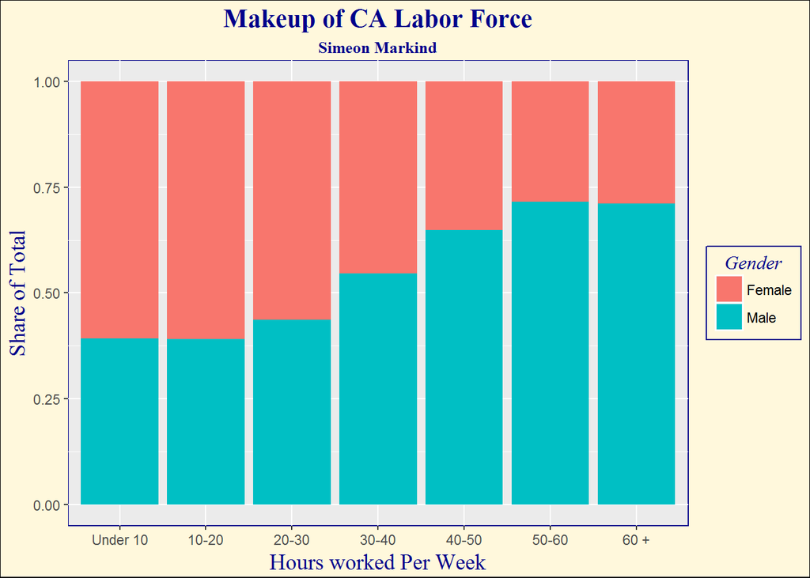

| Hours | Salary |
| --- | --- |
| Under 10 | 14,039.24 |
| 10-20 | 17,226.06 |
| 20-30 | 25,053.01 |
| 30-40 | 48,581.41 |
| 40-50 | 80,959.23 |
| 50-60 | 96,212.60 |
| 60 + | 88,548.91 |

Number of hours by itself will not fully explain income differentials, in addition to the number of hours worked, the field in which the person is employed will play a role in total income. One contributing factor to the income gap could be the fields in which each gender tends to work. For example, if women tend to work in lower paying industries and occupations than men, one would expect to see a gap on account of that. Let’s now take a look at the fields that each gender tends to work in.

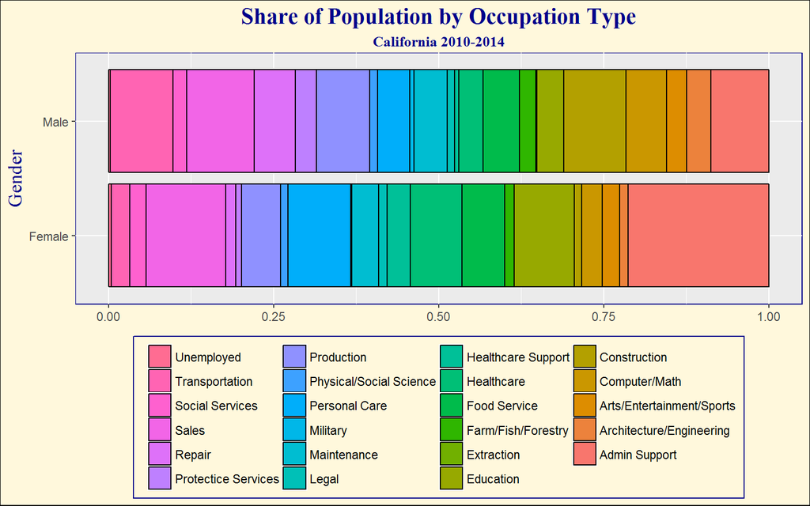

So firstly we notice that women are underrepresented in high paying fields such has Computer/Math and architecture and make less money in fields with equal representation, such as Legal. Even in fields with greater representation, such as Healthcare where women outnumber men about 2:1, women make about 70% as much as men do on average in the field. Now this is likely due to other factors such as type of profession (nurse vs. doctor), tenure in the position, and hours worked per week, but we still see a clear distinction in terms of salary as well as the types of occupations in which women and men sort themselves.

Let’s limit our sample some more by looking at income within age brackets and only looking at data for people who work at least 35 hours per week, which we will consider to be full time.

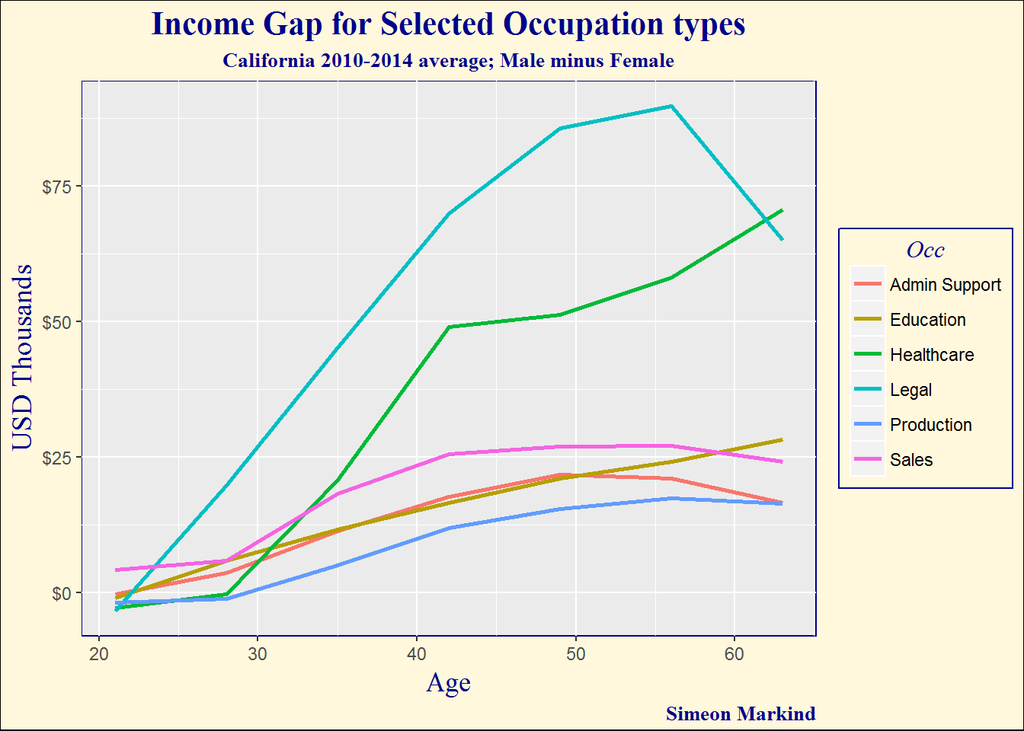

Note that while we do see the largest income gaps in the legal and healthcare fields, these are also the fields with the highest incomes. A graph of the percentage difference in pay would not show as large a gap of those two occupations vs. the other four. So we see here a clear trend of pay gaps being quite small at younger ages and then moderately increasing, (for Admin, Education, Production, and Sales), and sharply increasing for Healthcare and Legal.

It is less surprising that people now in their 50s see a large pay gap, (income differentials of 30 years ago have been compounded over the length of one’s entire career), but is the groudwork for that trend still in place? One way to look at this is to examine the rate of growth in incomes. If the growth rate of Female income is higher than that of males, over time the income gap would vanish. If the growth rates are equal at young ages, then a continuation of that trend would result in essentially no income gap. Unfortunately we only have 5 years of data so any trend cannot be assumed to hold over any long term.

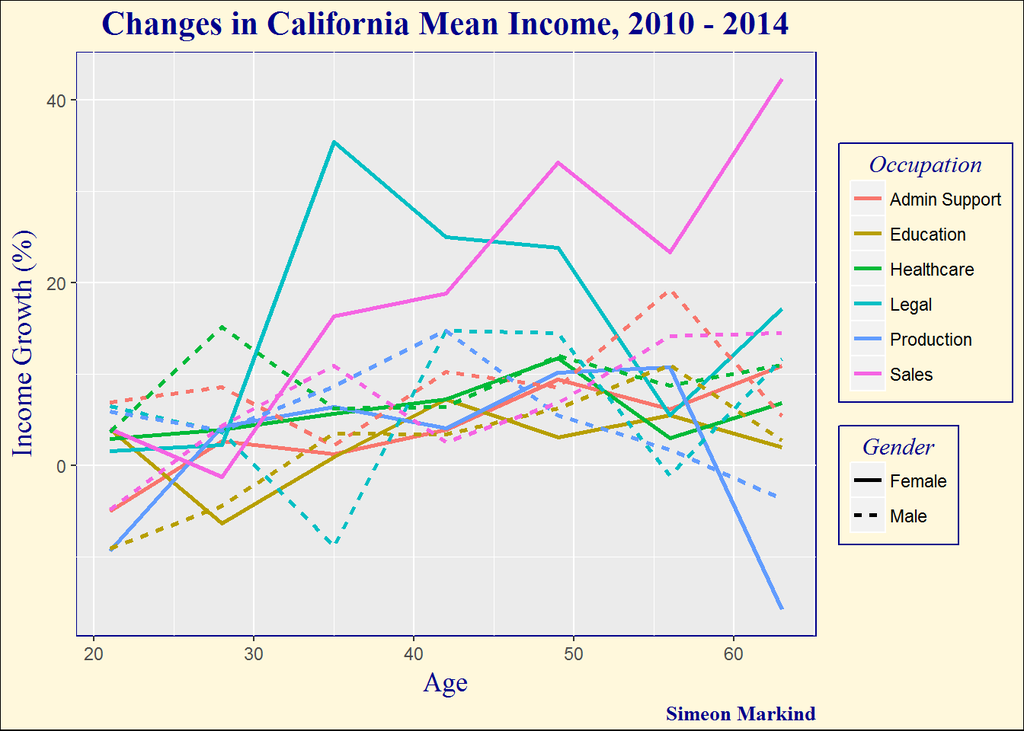

When we look at disparities in income gains over the period we do not see a clear pattern of gender differentiation for the six industries displayed.

Below is a table showing the change in incomes for all industries looking at the 2014 average vs. the 2010 average.

Income Growth Comparison

| Occupation | Growth % (F) | Growth % (M) | Growth $k (F) | Growth $k (M) | 2014 Count (F) | 2014 Count (M) |
| --- | --- | --- | --- | --- | --- | --- |
| Extraction | 69.82 | -7.16 | 17.65 | -4.12 | 343 | 2,921 |
| Personal Care | 23.75 | 6.45 | 9.69 | 5.48 | 97,626 | 87,537 |
| Farm/Fish/Forestry | 20.79 | 17.71 | 3.32 | 4.08 | 22,268 | 49,207 |
| Legal | 20.41 | 7.83 | 18.67 | 12.75 | 18,177 | 18,616 |
| Sales | 18.80 | 7.64 | 8.03 | 5.05 | 112,616 | 148,967 |
| Military | 15.38 | 0.00 | 5.65 | 0.00 | 1,087 | 11,431 |
| Computer/Math | 13.29 | 12.02 | 11.29 | 13.29 | 49,930 | 128,283 |
| Architecture/Engineering | 12.02 | 7.89 | 9.31 | 7.28 | 20,392 | 68,573 |
| Physical/Social Science | 10.66 | 12.27 | 7.10 | 9.06 | 14,725 | 20,602 |
| Maintenance | 9.71 | 7.86 | 2.52 | 2.37 | 38,677 | 74,568 |
| Construction | 7.65 | 5.62 | 4.38 | 2.38 | 18,066 | 152,509 |
| Arts/Entertainment/Sports | 6.70 | 15.19 | 4.00 | 11.19 | 29,250 | 45,247 |
| Repair | 6.31 | 8.61 | 4.23 | 4.53 | 24,288 | 104,250 |
| Healthcare | 5.99 | 10.02 | 4.47 | 10.97 | 109,041 | 66,925 |
| Healthcare Support | 4.98 | -7.91 | 1.53 | -3.54 | 38,586 | 9,273 |
| Admin Support | 4.98 | 8.80 | 2.04 | 4.41 | 254,808 | 136,169 |
| Production | 4.78 | 5.93 | 2.09 | 3.02 | 83,833 | 150,114 |
| Food Service | 3.82 | -3.01 | 1.03 | -1.06 | 49,690 | 69,775 |
| Education | 3.07 | 3.75 | 1.71 | 2.77 | 93,247 | 61,082 |
| Social Services | -0.66 | 0.90 | -0.38 | 0.71 | 33,597 | 33,596 |
| Transportation | -0.89 | 7.81 | -0.30 | 2.99 | 34,503 | 156,550 |
| Protectice Services | -2.38 | 2.83 | -1.35 | 1.87 | 11,512 | 51,899 |

When looking at average income gains by occupation type and gender over the period, the top five income gains, (in terms of greatest percentage growth), were all seen by women. As we saw before, women tend to earn less than men even in the same occupation type, so a larger percentage growth in income does not necessarily mean a larger growth in income in terms of raw dollars. In fact, we see that in both Farm/Fish/Forestry and Computer/Math women actually earned larger percentage income increases than men over the period but saw smaller increases in terms of raw dollars. However, if this trend continues, in the long term income will equilibrate.

Of note is the fact that no industry saw declining income for both women and men, all industries with negative growth for women saw positive growth for men, and vice versa.

Turning from looking at industry differentiation for income, let’s now look at mobility status and the demographic makeup of the state. Improved economic opportunities are one of the largest drivers for migration, so using the data we can look at what types of industries and incomes people who recently moved, (within the last year), have compared with people who did not move.

California Mobility Status 2014 by Gender

| Gender | Status vs. One Year Prior | Count | Percent |
| --- | --- | --- | --- |
| Female | Foreign | 12,673 | 0.56 |
| Male | Foreign | 16,630 | 0.68 |
| Female | In State | 282,279 | 12.53 |
| Male | In State | 307,618 | 12.49 |
| Female | In US | 32,014 | 1.42 |
| Male | In US | 39,845 | 1.62 |
| Female | Non-movers | 1,925,461 | 85.48 |
| Male | Non-movers | 2,098,169 | 85.21 |

Let’s now take a look at movers vs. non-movers. We’ll define a mover as anyone who is not in the same residence as they were one year ago.

Non-Movers tend to earn more than movers

| Gender | Status | Income $K |
| --- | --- | --- |
| Female | Non-mover | 38.21 |
| Female | mover | 32.66 |
| Male | Non-mover | 56.14 |
| Male | mover | 45.66 |

So in fact what we see if the opposite, in general non-movers tend to make more than movers, likely because people are more mobile earlier in their careers and less later on, when they are likely to have higher incomes than their younger colleagues. Let’s take a look at the same table but this time restrict the sample to only those between the ages of 20 and 35.

Age Restricted to 20-35

| Gender | Status | Mean Income ($K) | Count |
| --- | --- | --- | --- |
| Female | Non-mover | 28.42 | 2,398,618 |
| Female | mover | 28.62 | 848,951 |
| Male | Non-mover | 34.43 | 2,792,828 |
| Male | mover | 36.26 | 961,286 |

Part of one’s mobility status can be tied to employment, for example someone who works in a large company could move offices or someone who works in a highly volatile industry, such as natural resource extraction, may have to move frequently to where the resources are located. Below we show the top six industries in terms of female mobility - the six industries with the largest percentage of women indicating they no longer live in the same location as one year prior.

Yearly Average Percentage of Movers

| Occupation | Female | Male |
| --- | --- | --- |
| Military | 45.81 | 44.72 |
| Extraction | 27.50 | 25.51 |
| Unemployed | 24.42 | 19.51 |
| Food Service | 21.96 | 20.22 |
| Arts/Entertainment/Sports | 19.96 | 19.59 |
| Physical/Social Science | 19.88 | 19.24 |

(Don’t really think this table adds anything to be honest)

While previously we looked at California on the whole, we can also look at income differentiation at a geographic level. For now we will look at county level differentiation in order to maintain a larger sample size. Luckily, California’s economy is highly diverse geographically with counties in the bay area focused on technology, those inland focused on agriculture, those in the Los Angeles area focused in media and entertainment sector, etc. When looking at a county level disambiguation of income we can also see if the income gap is more or less pronounced in areas where overall income is higher or lower. Perhaps wealthy areas do not see the same disparities as poorer counties.

Top 5 Counties by Female Mean Income

| County | Female | Male | Income Ratio M/F |
| --- | --- | --- | --- |
| Marin | 59,529.82 | 93,016.15 | 1.56 |
| San Francisco | 52,903.51 | 72,398.13 | 1.37 |
| San Mateo | 52,799.37 | 76,141.69 | 1.44 |
| Santa Clara | 48,412.03 | 76,623.34 | 1.58 |
| Contra Costa | 44,089.98 | 70,396.92 | 1.60 |

Bottom 5 Counties by Female Mean Income

|  | County | Female | Male | Income Ratio M/F |
| --- | --- | --- | --- | --- |
| 41 | Tehama | 24,261.55 | 37,121.91 | 1.53 |
| 42 | Mendocino | 24,134.84 | 36,100.44 | 1.50 |
| 43 | Tulare | 24,010.62 | 34,272.96 | 1.43 |
| 44 | Siskiyou | 23,767.83 | 34,465.57 | 1.45 |
| 45 | Imperial | 23,294.35 | 32,549.79 | 1.40 |

Unsurprisingly we see that the counties in which women make the most money are also the ones where men make the most money. The ratio of the average male income to female income is slightly higher in the five counties where women have the highest average incomes meaning that the relative income gap is more pronounced in the wealthiest counties than in poorest ones.

Moving beyond geography, perhaps market concentration plays a factor in income inequality, perhaps areas where a higher concentration of the workforce is women have more women in management and decision making position with regards to salary. These could then be more likely to see a more equitable income ratio than those that are more male dominated. Below we see that this does not appear to be the case.

Counties with highest Female share of population

| County | Female Income | Male Income | Female Share | Income Ratio: M/F |
| --- | --- | --- | --- | --- |
| Sacramento | 34.46 | 45.13 | 50.14 | 1.31 |
| Yolo | 31.96 | 48.95 | 50.05 | 1.53 |
| Shasta | 27.08 | 39.42 | 49.90 | 1.46 |
| Placer | 39.39 | 62.54 | 49.75 | 1.59 |
| Marin | 59.53 | 93.02 | 49.41 | 1.56 |
| Solano | 35.60 | 47.82 | 49.23 | 1.34 |

Counties with lowest Female share of population

| County | Female Income | Male Income | Female Share | Income Ratio: M/F |
| --- | --- | --- | --- | --- |
| San Diego | 36.24 | 54.06 | 46.54 | 1.49 |
| Monterey | 31.97 | 44.98 | 46.49 | 1.41 |
| Kern | 26.38 | 40.76 | 46.37 | 1.55 |
| Santa Clara | 48.41 | 76.62 | 46.33 | 1.58 |
| Siskiyou | 23.77 | 34.47 | 44.99 | 1.45 |
| Kings | 26.69 | 37.99 | 42.88 | 1.42 |

Ratio of Male to Female income earners does not seem to be particularly correlated with the ratio of income. Sacramento county, where women make up over 50% of income earners has an income only slightly lower than Kings county, where women make up only 43% of income earners.

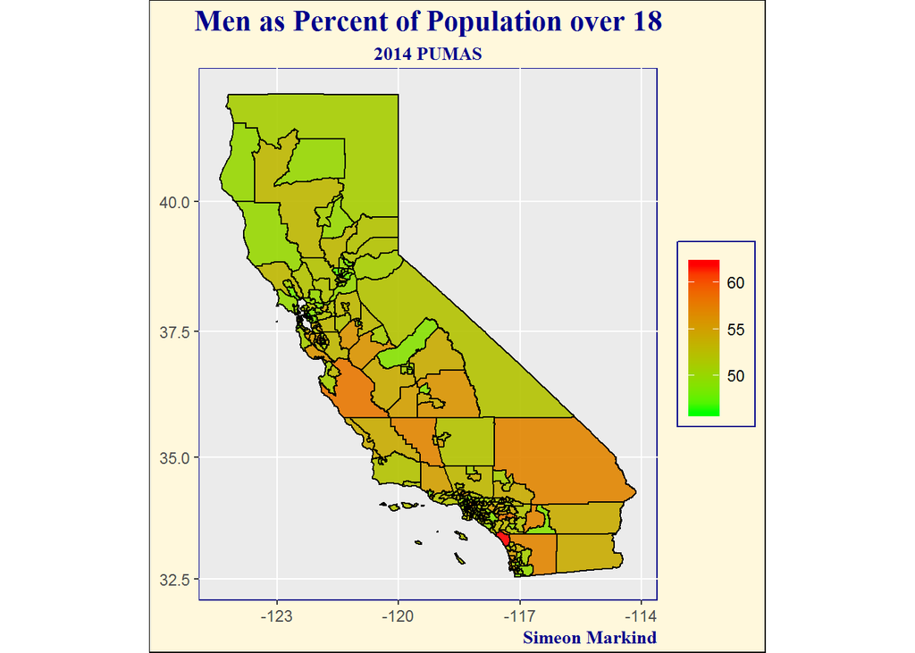

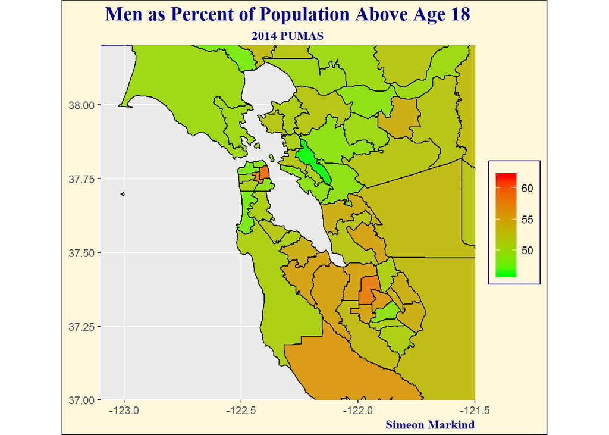

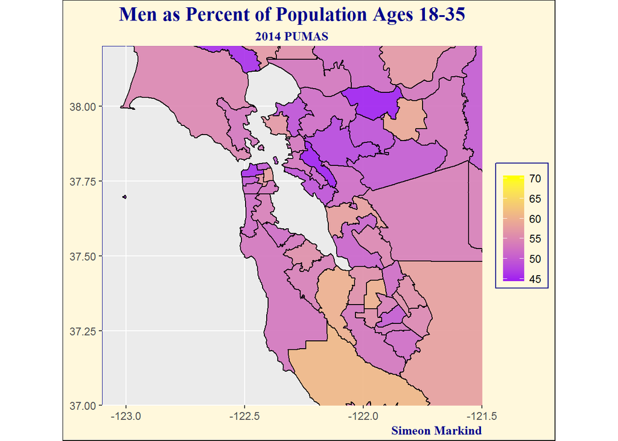

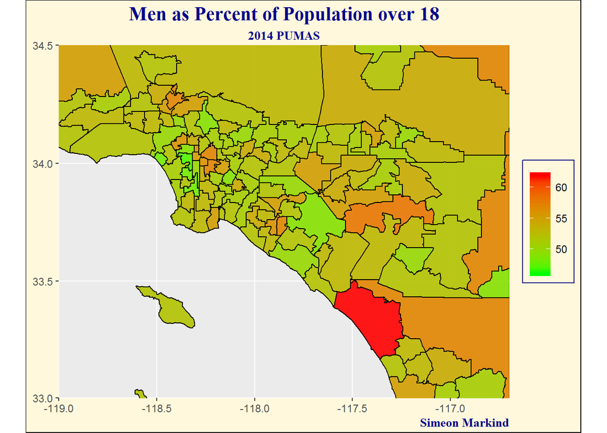

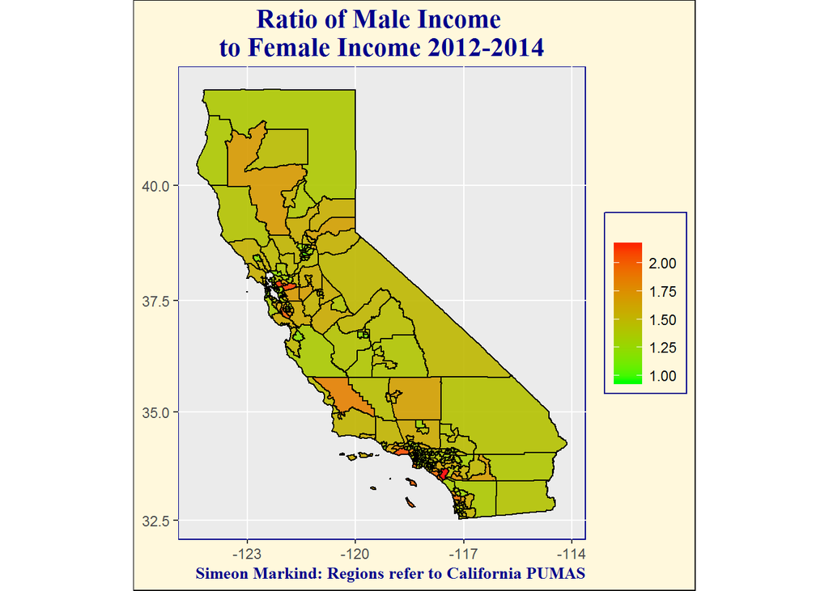

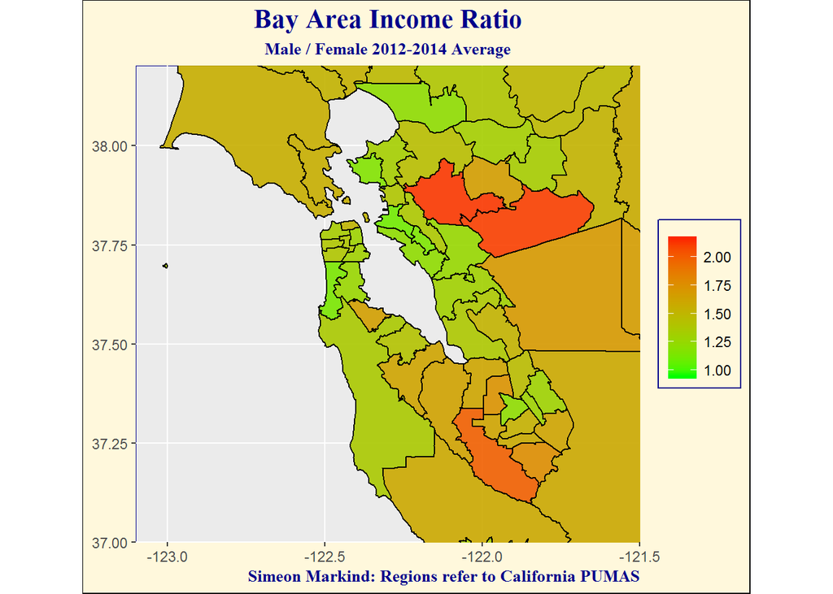

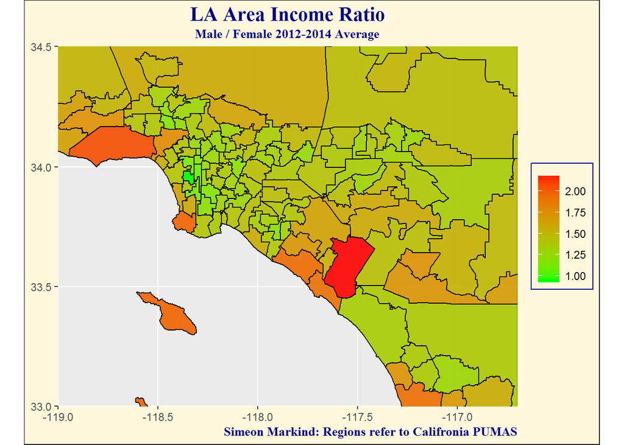